# Posterior comparison methods

Adam Howes

Abstract

**Background** Multiple approaches for conducting approximate Bayesian inference exist.

**Task** We compare methods for assessing the accuracy of posterior distribution. These methods include marginal KS tests, simulation based calibration and maximum mean discrepancy.

# 1 Background

There are lots of ways you can compare posterior distributions.

The simplest is to compare point estimates (such as the mean or mode) or moments (such as the variance). In some sense, it’s the least we should expect from any good approximate Bayesian inference method to be able to recover these summaries.

More challenging is to match the distribution everywhere. One way to assess this is the Kolmogorov-Smirnov (KS) distance, which gives the maximum distance between two empirical cumulative distribution functions (ECDFs). It is directly interpretable: a value of 0.05 means that no matter where you compute a tail probability, you’re never more than 5% away.

A downside of the KS distance is that it only captures marginal distributions. This, in some way, favors methods like INLA where we directly approximate marginals. A further challenge would be to assess agreement between joint distributions, rather than only marginals.

# 2 Data

Throughout this notebook we will use exemplar data from the report [`dev_sinla`](https://github.com/athowes/naomi-aghq/tree/master/src/dev_sinla).

```r
samples <- readRDS("depends/model1-samples-m250.rds")
samples_mcmc <- samples$mcmc
samples_gaussian <- samples$gaussian
samples_laplace <- samples$laplace
```

# 3 KS tests

Compute the empirical CDFs, and look for the maximum distance between them.

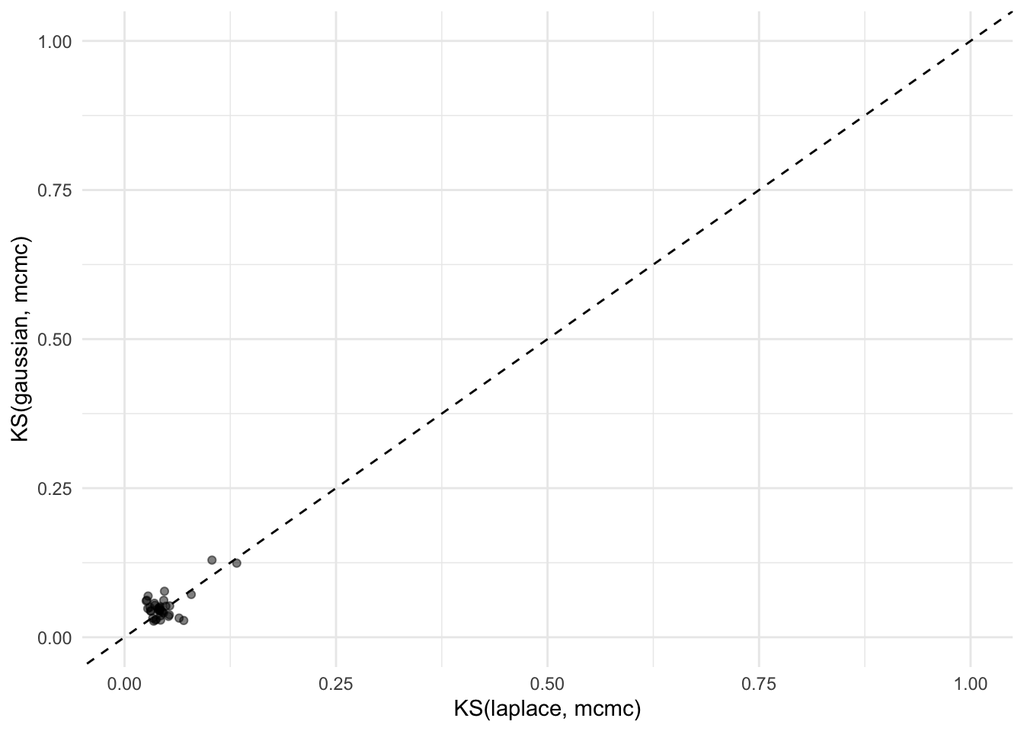

```r
n <- length(unique(samples_mcmc$index))

ks_gaussian_mcmc <- lapply(1:n, function(i) {
  samples_gaussian_i <- filter(samples_gaussian, index == i)$value
  samples_mcmc_i <- filter(samples_mcmc, index == i)$value
  inf.utils::ks_test(samples_gaussian_i, samples_mcmc_i)
})

ks_laplace_mcmc <- lapply(1:n, function(i) {
  samples_laplace_i <- filter(samples_laplace, index == i)$value
  samples_mcmc_i <- filter(samples_mcmc, index == i)$value
  inf.utils::ks_test(samples_laplace_i, samples_mcmc_i)
})

ks_results <- bind_rows(
  bind_rows(ks_gaussian_mcmc, .id = "index") %>%
    mutate(type = "gaussian"),
  bind_rows(ks_laplace_mcmc, .id = "index") %>%
    mutate(type = "laplace")
)

ks_results %>%
  select(index, D, type) %>%
  pivot_wider(
    names_from = type,
    values_from = D
  ) %>%
  ggplot(aes(x = laplace, y = gaussian)) +
    geom_point(alpha = 0.5) +
    geom_abline(intercept = 0, slope = 1, linetype = "dashed") +
    lims(x = c(0, 1), y = c(0, 1)) +
    labs(x = "KS(laplace, mcmc)", y = "KS(gaussian, mcmc)") +
    theme_minimal()
```

```r
ks_results %>%
  group_by(type) %>%
  summarise(mean = mean(D)) %>%
  knitr::kable()
```

| type | mean |
| --- | --- |
| gaussian | 0.0509201 |
| laplace | 0.0464028 |